# Democratic Backsliding and Foreign Aid

Joe Hoskisson and Sania Bala

## Research Question & Motivation

**What are we trying to learn?**

> Does democratic backsliding cause countries to receive less foreign aid?

**Why does it matter?**

- Democratization. Liberalism view would require certain reforms to get aid.
- Punishment. Do donors hold governments accountable when they violate democratic norms?
- Reward. Does more OECD aid go to governments that are becoming more democratic?

## Data

**Sources**

| Dataset | What it provides |
| --- | --- |
| V-Dem (Coppedge et al.) | Country-year democracy indices and governance measures |
| OECD DAC2A | Total ODA disbursements by recipient country and year |
| World Bank WDI | GDP per capita and population |

*ODA (Official Development Assistance) refers to total aid received by developing countries from donor governments. It includes grants, concessional loans, and technical assistance.*

**Sample**

- Unit of analysis: **country-year**
- Period: **2010–2020**
- Final N: **1336 country-years**

## Key Variables

| Role | Variable | Description |
| --- | --- | --- |
| Outcome | oda_count | Total ODA received (USD millions, rounded) |
| Key predictor | delta_polyarchy | Year-over-year change in electoral democracy (V-Dem) |
| Control | v2x_polyarchy | Electoral democracy level (V-Dem) |
| Control | v2x_corr | Political corruption index (V-Dem) |
| Control | v2x_rule | Rule of law index (V-Dem) |
| Control | v2xcl_rol | Civil liberties / equality before the law (V-Dem) |
| Control | log(gdp_per_capita) | Log GDP per capita, constant 2015 USD (World Bank) |
| Control | log(population) | Log population (World Bank) |

## Outcome & Model Choice

**What kind of outcome do we have?**

- ODA is a **non-negative count** (USD millions, rounded to nearest integer)
- Highly right-skewed — a small number of countries receive enormous amounts; most receive relatively little
- **Overdispersion:** variance far exceeds the mean, which violates the Poisson assumption

**Which model are we fitting?**

- **Negative binomial regression** — extends Poisson by adding a dispersion parameter (θ) that absorbs excess variance
- Confirmed: Poisson residual deviance = 36,501,834 on 1,211 df; NB residual deviance = 1,425 on 1,211 df

## Preliminary Results: Coefficient Table

| Predictor | Estimate | Std. Error | p-value |
| --- | --- | --- | --- |
| Backsliding (Δ democracy) | 0.299 | 0.599 | 0.618 |
| Democracy level | -1.252 | 0.229 | <.001 |
| Corruption | 1.120 | 0.253 | <.001 |
| Rule of law | 2.029 | 0.335 | <.001 |
| Civil liberties | -0.141 | 0.209 | 0.5 |
| log(GDP per capita) | -0.493 | 0.027 | <.001 |
| log(Population) | 0.476 | 0.016 | <.001 |

## Preliminary Results: Predicted Values Plot

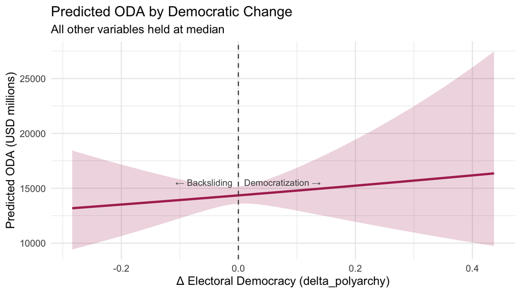

## Interpreting the Results

- `delta_polyarchy` is **not significant** (est. = 0.299, p = .618)
- Direction is correct — backsliding predicts less aid, democratization predicts more
- But the effect is too small and uncertain to distinguish from zero
- **Substantive interpretation:** donors respond to *where* a country sits on the democracy scale, not to *how fast* it is moving

## What We’re Stuck On & What’s Next

**Things we are still working through**

- Should we test **alternative democracy indices** (e.g., liberal, participatory) in the VDEM dataset to assess whether results are sensitive to how democracy is measured?
- Should we **extend the backsliding measure** to capture cumulative democratic decline over a 3–5 year window, rather than year-over-year change, to better reflect how donors perceive and respond to backsliding?
- Should we look at the differences between **commitments** and **disbursement** of aid as democracy ratings change?